# AS04_Data-join-Visualizing-Date-Time

B10610017 劉宇凡

2024/03/25

## 作業目的:

這份作業包含兩部分，第一個是希望大家練習data-join的使用方法，第二部分則是時間資料的視覺化。

## Part 1 ：剖析雙主修資料

資料介紹：這份資料改編自台大 105 學年度雙主修的榜單，請參考[雙主修榜單](https://reg227.aca.ntu.edu.tw/TMD/stuquery/doc/105%E9%9B%99%E4%B8%BB%E4%BF%AE%E6%A6%9C%E5%96%AE.pdf)，但是 105 年的掛了，給你看 [108年](http://reg227.aca.ntu.edu.tw/tmd/stuquery/doc/108%E9%9B%99%E4%B8%BB%E4%BF%AE%E6%A6%9C%E5%96%AE.pdf) 作為參考。

```r
library(dplyr)
### 這邊不要動
df_college_join <- read.csv("data/df_college_join.csv")
df_dmajor_105 <- read.csv("data/df_dmajor_105.csv")

### 給你看資料長這樣
df_college_join %>% head(5) # 學院與系所對應表
df_dmajor_105 %>% head(5) # 雙主修資料
```

```
#>    college       dept
#> 1 公衛學院     公衛系
#> 2   工學院     化工系
#> 3   工學院     土木系
#> 4   工學院 工科海洋系
#> 5   工學院     材料系
#>   ID_year ID_dept ID_order dept_original grade  name dept_dmajor
#> 1    <NA>    <NA>       NA          <NA>    NA 陳O薇        <NA>
#> 2    <NA>    <NA>       NA        資工所    NA 楊O晨      新聞所
#> 3     B02     A01      314  法律系財法組     4 蔡O軒      哲學系
#> 4     B01     B01       76  法律系財法組     4 呂O禹      生科系
#> 5     B03     A01      361  法律系財法組     3 于O庭      哲學系
```

### 1.尋找並處理 `NA`

你應該有看到這題所給的`df_dmajor_105`資料中包含`NA`，但因為會影響到後續的計算，因此要請你把`df_dmajor_105`中有`NA`的資料全部刪除。請你印出刪除後的資料筆數。並將新資料重新存到`df_dmajor_105`

```r
library(tidyverse)

df_dmajor_105 <- df_dmajor_105 %>%
    filter(complete.cases(.))

nrow(df_dmajor_105)

# result
# [1] 498
```

```
#> [1] 498
```

### 2.尋找向外雙主修人數最多的系所:

利用 `df_dmajor_105` 請幫我找出**向外**雙主修**人數最多**的系所  
＊向外指的是該系有最多學生雙主修其他科系 ＊本題等於要找哪個系有最多學生雙主修其他科系

> 參考作法：`group_by()` and `summarize()`

```r
### your code
df_dmajor_105 %>%
    group_by(dept_original) %>%
    summarize(number = n()) %>%
    filter(number == max(number))

### result
```

[output not shown]

```
#> # A tibble: 1 × 2
#>   dept_original number
#>   <chr>          <int>
#> 1 森林環資系        27
```

### 3.計算各學院之間雙主修的人數

請幫我串接 `df_dmajor_105` 和 `df_college_join`，接著計算各學院之間雙主修的人數，將結果儲存成 `df_dmajor_105_college` 並印出。

> 參考作法: 需使用 ???_join() 函數，應該會做資料串接做「兩次」（也就是兩次???_join()）。一次是要將原系所（dept_original）與學院系所對應表串連，一次是要將雙主修的系所（dept_dmajor）與學院系所對應表做串連。 ???_join有很多種，務必清楚了解每一類join的用意，才不會搞錯唷。

```r
### your code
df_dmajor_105_college <- df_dmajor_105 %>%
    left_join(df_college_join, by = c("dept_original" = "dept")) %>%
    left_join(df_college_join, by = c("dept_dmajor" = "dept")) %>%
    rename(
        college_original = college.x,
        college_dmajor = college.y
           ) %>%
    group_by(college_original, college_dmajor) %>%
    count()

print(df_dmajor_105_college)

### your result should be
```

```
#> # A tibble: 70 × 3
#>    college_original college_dmajor     n
#>    <chr>            <chr>          <int>
#>  1 公衛學院         生科學院           1
#>  2 工學院           工學院             6
#>  3 工學院           文學院             3
#>  4 工學院           理學院             7
#>  5 工學院           生農學院           1
#>  6 工學院           社科院             7
#>  7 工學院           管理學院           3
#>  8 工學院           電資學院           3
#>  9 文學院           公衛學院           1
#> 10 文學院           工學院             1
#> # … with 60 more rows
```

```
#> # A tibble: 70 × 3
#> # Groups:   college_original, college_dmajor [70]
#>    college_original college_dmajor     n
#>    <chr>            <chr>          <int>
#>  1 公衛學院         生科學院           1
#>  2 工學院           工學院             6
#>  3 工學院           文學院             3
#>  4 工學院           理學院             7
#>  5 工學院           生農學院           1
#>  6 工學院           社科院             7
#>  7 工學院           管理學院           3
#>  8 工學院           電資學院           3
#>  9 文學院           公衛學院           1
#> 10 文學院           工學院             1
#> # ℹ 60 more rows
```

### 4.清理資料：寬表格轉換

請將 `df_dmajor_105_college` 轉成寬表格後印出，表格中的值使用 `n`，看各系所之間互相雙主修的情形

> 參考作法: `spread()` or `pivot_wider()`

```r
### your code
df_dmajor_105_college <- df_dmajor_105_college %>%
    pivot_wider(names_from = college_dmajor, values_from = n) %>%
    mutate_all(~ifelse(is.na(.), 0, .))

print(df_dmajor_105_college)

### your result should be
```

```
#> # A tibble: 10 × 11
#>    college_original 生科學院 工學院 文學院 理學院 生農學院 社科院 管理學院
#>    <chr>               <int>  <int>  <int>  <int>    <int>  <int>    <int>
#>  1 公衛學院                1      0      0      0        0      0        0
#>  2 工學院                  0      6      3      7        1      7        3
#>  3 文學院                  1      1     44      3        6     40        6
#>  4 法學院                  1      0     10      0        1      7        3
#>  5 理學院                  2      8      8     17        6      8        1
#>  6 生農學院                5      9     11     13       39     19        3
#>  7 社科院                  0      1     13      6        5     37        8
#>  8 管理學院                4      0     13      7        1     10       10
#>  9 醫學院                  0      0      3      3        4      3        2
#> 10 電資學院                0      1      3     15        5      1        5
#> # … with 3 more variables: 電資學院 <int>, 公衛學院 <int>, 法學院 <int>
```

```
#> # A tibble: 10 × 11
#> # Groups:   college_original [10]
#>    college_original 生科學院 工學院 文學院 理學院 生農學院 社科院 管理學院
#>    <chr>               <dbl>  <dbl>  <dbl>  <dbl>    <dbl>  <dbl>    <dbl>
#>  1 公衛學院                1      0      0      0        0      0        0
#>  2 工學院                  0      6      3      7        1      7        3
#>  3 文學院                  1      1     44      3        6     40        6
#>  4 法學院                  1      0     10      0        1      7        3
#>  5 理學院                  2      8      8     17        6      8        1
#>  6 生農學院                5      9     11     13       39     19        3
#>  7 社科院                  0      1     13      6        5     37        8
#>  8 管理學院                4      0     13      7        1     10       10
#>  9 醫學院                  0      0      3      3        4      3        2
#> 10 電資學院                0      1      3     15        5      1        5
#> # ℹ 3 more variables: 電資學院 <dbl>, 公衛學院 <dbl>, 法學院 <dbl>
```

## Part2：Datetime Visualization

這份作業希望能夠讓你熟悉於處理日期與時間資料，並且利用視覺化的文法(grammar of graphics) 呈現結果。過程中會用到前幾週學過 dplyr 的動詞，以及 lubridate 和 ggplot2。每個小題都請寫下你的原始碼並且畫出圖表。

這次的作業使用 readr 提供的[原始資料](https://github.com/readr-media/readr-data/tree/master/movie_tickets)，主題是台灣的電影票房，有興趣的話可以點進[【數讀國片票房】全球影視寒冬，2020臺灣電影如何逆勢崛起](https://www.readr.tw/post/2522) 看一下這篇資料新聞。每一個小題都是新聞上的一張圖表！

```r
### 這邊不要動
library(tidyverse)
library(lubridate)
library(ggthemes)

df_movie_raw <- read_csv("data/movie_tickerts_2017_2020.csv")
### 給你看資料長這樣
df_movie_raw %>% glimpse()
```

```
#> Rows: 15,704
#> Columns: 16
#> $ name         <chr> "全國電影票房2017年10021008統計資訊", "全國電影票房2017年…
#> $ 國別地區     <chr> "中國大陸", "中華民國", "中華民國", "香港", "中華民國", "…
#> $ 中文片名     <chr> "我在故宮修文物", "乒乓", "林投記", "追龍", "老師你會不會…
#> $ 上映日期     <date> 2017-10-02, 2017-10-02, 2017-10-02, 2017-09-29, 2017-09-…
#> $ 申請人       <chr> "岸上影像有限公司", "財團法人公共電視文化事業基金會", "財…
#> $ 出品         <chr> "杭州潛影文化創意有限公司##故宮博物院##天津貓眼文化傳媒有…
#> $ 上映院數     <dbl> 9, 1, 1, 67, 78, 58, 81, 10, 5, 10, 8, 3, 5, 3, 7, 4, 4, …
#> $ 銷售票數     <dbl> 570, 295, 275, 86861, 52922, 26034, 16119, 3101, 1253, 10…
#> $ 銷售金額     <dbl> 129103, 58250, 54130, 19872900, 11852483, 5918703, 371839…
#> $ 累計銷售票數 <dbl> 616, 382, 354, 136853, 100844, 45571, 31218, 4993, 1915, …
#> $ 累計銷售金額 <dbl> 136143, 75340, 69440, 31110909, 22419756, 10319396, 71809…
#> $ end_date     <date> 2017-10-08, 2017-10-08, 2017-10-08, 2017-10-08, 2017-10-…
#> $ year         <dbl> 2017, 2017, 2017, 2017, 2017, 2017, 2017, 2017, 2017, 201…
#> $ start_date   <date> 2017-10-02, 2017-10-02, 2017-10-02, 2017-10-02, 2017-10-…
#> $ end_year     <dbl> 2017, 2017, 2017, 2017, 2017, 2017, 2017, 2017, 2017, 201…
#> $ screen_year  <dbl> 2017, 2017, 2017, 2017, 2017, 2017, 2017, 2017, 2017, 201…
```

### 1. `geom_line()`:

請參考 readr 的圖表，畫出台灣 2017/10 ~ 2020/11 每週的放映數量，並且用不同顏色的曲線表示年份，其中 2020 年的曲線以實線表示，2017 - 2019 年的曲線則以虛線(dotted line)表示。

可以參考 data -> plot_01.jpg，或者直接看 readr 報導當中標題為「臺灣電影每週放映數量」的圖表。因為週次計算方式可能有差異，因此不要求和 readr 計算出的數字完全相同，呈現類似趨勢即可。週次的計算方式可以挑選 **`start_date`** 作為基準。

keywords： `geom_line()`, `week()`, `color = ?`, `linetype = ?`

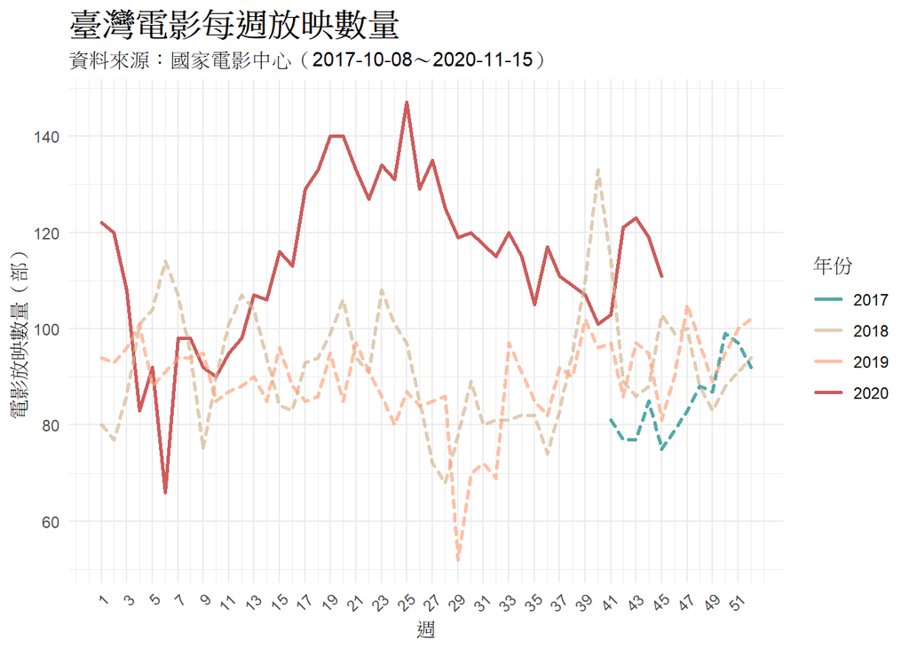

[figure not shown]

```r
### your code
df_week_released <- df_movie_raw %>%
    filter(complete.cases(.)) %>%
    filter(start_date >= as.Date("2017-10-08")) %>%
    mutate(week = week(start_date)) %>%
    arrange(year(start_date), week) %>%
    group_by(year, week) %>%
    count() %>%
    rename(number = n) %>%
    mutate(year = as.character(year))

df_week_released %>%
    ggplot(aes(x = week, y = number, color = year)) +
    geom_line(linestart = "round", lineend = "round", linejoin = "round", size = 0.9, aes(linetype = ifelse(year %in% c("2017", "2018", "2019"), "solid", "dashed"))) +
    scale_color_manual(values = c("2017" = "#007F7FAA", "2018" = "#D2B48CAA", "2019" = "#FFA07AAA", "2020" = "#CD5C5C")) +
    labs(title = "臺灣電影每週放映數量",
         subtitle = "資料來源：國家電影中心（2017-10-08～2020-11-15）",
         x = "週",
         y = "電影放映數量（部）",
         color = "年份") +
    guides(linetype = FALSE) +
    scale_x_continuous(limits = c(1, 52), breaks = seq(1, 52, by = 2)) +
    scale_y_continuous(breaks = seq(0, 150, by = 20)) +
    theme_minimal() +
    theme(text = element_text(family = "Arial"),
          axis.text.x = element_text(angle = 45, hjust = 1),
          plot.title = element_text(face = "bold", size = 18))
```

### 2. `geom_bar()` or `geom_col()`:

請參考 readr 的圖表，畫出台灣 2017 - 2020 每年所有電影票房與國片票房的長條圖，並以併排(dodge)方式呈現。

可以參考 data -> plot_02.jpg，或者直接看 readr 報導當中標題為「臺灣的電影銷售票房變化」的圖表。本題要求和 readr 的數字幾乎相同（2018年有可能會有一點點誤差）。年份的計算方式可以挑選 **`start_date`** 作為基準。

keywords： `geom_bar/col()`, `year()`, `fill = ?`

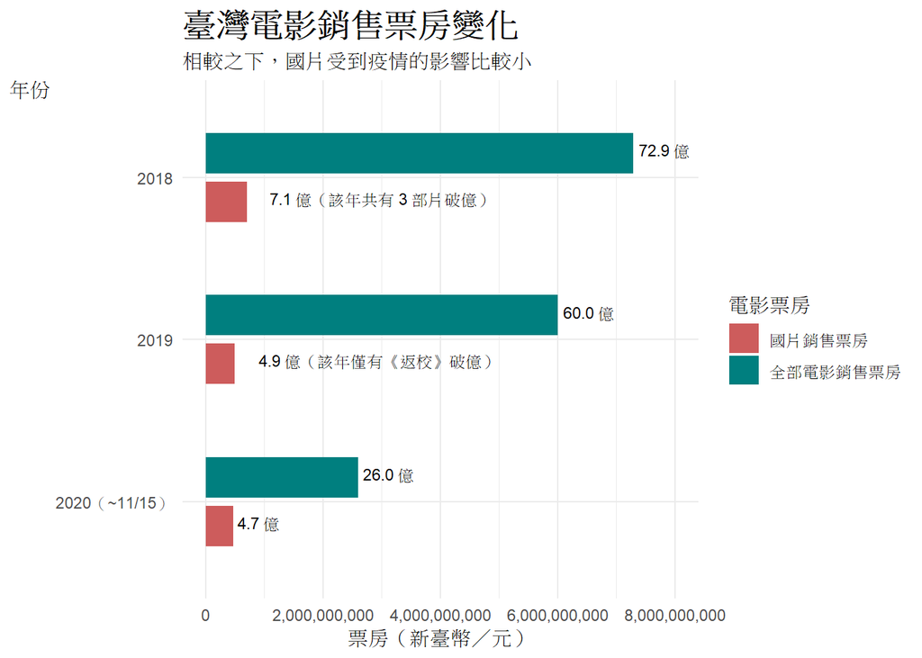

[figure not shown]

```r
### your code
# 整理 dataframe 並儲存為 df_box_office
df_box_office <- df_movie_raw %>%
    rename(boxoffice = 銷售金額, country = 國別地區) %>%
    filter(year != 2017) %>%
    group_by(year, country) %>%
    summarize(total_movie = sum(boxoffice)) %>%
    filter(complete.cases(total_movie)) %>%
    mutate(region = if_else(str_detect(country, "中華民國"), "國片銷售票房", "國外電影銷售票房")) %>%
    group_by(year, region) %>%
    summarize(total_boxoffice = sum(total_movie)) %>%
    pivot_wider(names_from = region, values_from = total_boxoffice) %>%
    mutate(全部電影銷售票房 = 國片銷售票房 + 國外電影銷售票房) %>%
    select(year, 全部電影銷售票房, 國片銷售票房) %>%
    pivot_longer(cols = c("全部電影銷售票房", "國片銷售票房"), names_to = "電影票房", values_to = "boxoffice")

# 繪製橫的長條圖
df_box_office %>%
    ggplot(aes(x = fct_relevel(as.factor(year), "2020", "2019", "2018"), y = boxoffice, fill = fct_relevel(電影票房, "國片銷售票房", "全部電影銷售票房"))) +
    geom_bar(stat = "identity", position = position_dodge(width = 0.6), width = 0.5) +
    geom_text(aes(label = case_when(year == "2018" & 電影票房 == "國片銷售票房" ~ paste(round(boxoffice/(10^8), 1), "億（該年共有 3 部片破億）", sep = " "),
                                    year == "2019" & 電影票房 == "國片銷售票房" ~ paste(round(boxoffice / (10^8), 1), "億（該年僅有《返校》破億）", sep = " "),
                                    year == "2019" & 電影票房 == "全部電影銷售票房" ~ paste0(round(boxoffice/(10^8), 1), ".0 億"),
                                    year == "2020" & 電影票房 == "全部電影銷售票房" ~ paste0(round(boxoffice/(10^8), 1), ".0 億"),
                                    TRUE ~ paste(as.character(round(boxoffice / (10^8), 1)), "億", sep = " "))),
              position = position_dodge(width = 0.6), vjust = 0.2, hjust = -0.1, color = "black", size = 3) +
    scale_fill_manual(values = c("#CD5C5C", "#007F7F")) +
    labs(title = "臺灣電影銷售票房變化",
         subtitle = "相較之下，國片受到疫情的影響比較小",
         x = "年份",
         y = "票房（新臺幣／元）",
         fill = "電影票房") +
    scale_y_continuous(labels = scales::comma, breaks = seq(0, 8000000000, by = 2000000000), limits = c(0, 8000000000)) +
    scale_x_discrete(labels = c("2020（~11/15）", "2019", "2018")) +
    theme_minimal() +
    theme(axis.title.y = element_text(angle = 0),
          plot.title = element_text(face = "bold", size = 18)) +
    coord_flip()
```

### 3. `geom_bar()` or `geom_col()`:

請參考 readr 的圖表，畫出台灣 2017 - 2020 每年國片上映院數的中位數長條圖。 可以參考 data -> plot_03.jpg，或者直接看 readr 報導當中標題為「國片上映院數是否有增加？」的圖表。理論上和 readr 的數字相同，若**數字不同請說明原因。**上映日期的計算方式可以直接使用 **`上映日期`** 欄位。

不過這裡有一個小地方需要注意，以「紅衣小女孩2」為例，這筆資料中會有像是這樣的逐週紀錄：

```
# A tibble: 8 × 5
  name                               中文片名    上映院數 上映日期    year ...
  <chr>                              <chr>          <dbl> <date>     <dbl> ...
1 全國電影票房2017年10021008統計資訊 紅衣小女孩2       23 2017-08-25  2017 ...
2 全國電影票房2017年10091015統計資訊 紅衣小女孩2       10 2017-08-25  2017 ...
3 全國電影票房2017年11271203統計資訊 紅衣小女孩2        8 2017-08-25  2017 ...
4 全國電影票房2017年12041210統計資訊 紅衣小女孩2       10 2017-08-25  2017 ...
5 全國電影票房2017年12111217統計資訊 紅衣小女孩2       10 2017-08-25  2017 ...
6 全國電影票房2017年12181224統計資訊 紅衣小女孩2        7 2017-08-25  2017 ...
7 全國電影票房2017年12251231統計資訊 紅衣小女孩2        1 2017-08-25  2017 ...
8 2017年9月前資訊                    紅衣小女孩2       85 2017-08-25  2017 ...
```

請以上映院數最大的那週(max)的值進行計算。

keywords： `geom_bar/col()`, `year()`, `fill = ?`

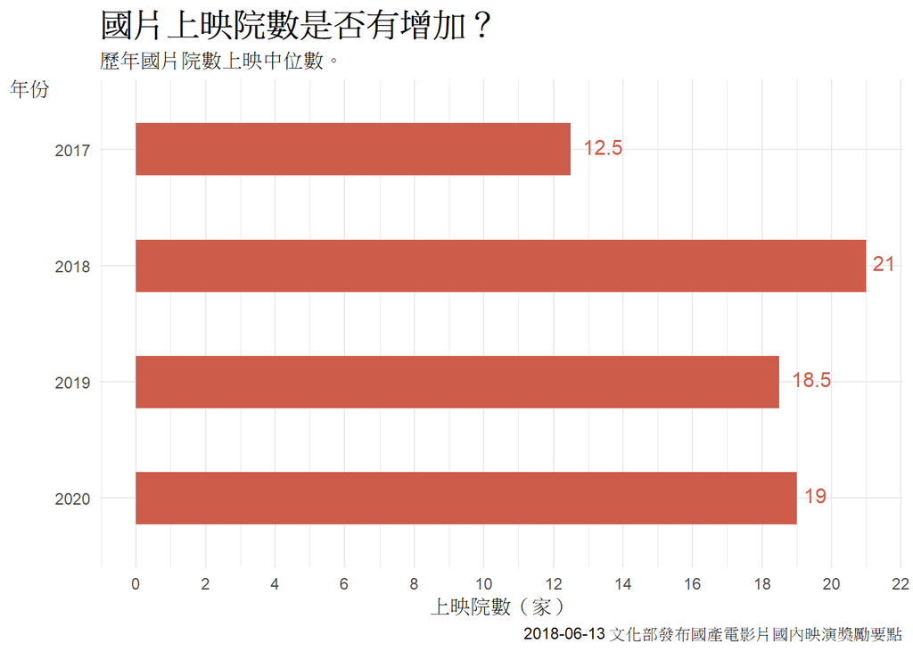

[figure not shown]

```r
### your code
df_theaters_median <- df_movie_raw %>%
    rename(movie = 中文片名,
           released_date = 上映日期,
           country = 國別地區,
           theaters = 上映院數) %>%
    mutate(type = if_else(str_detect(country, "中華民國"), "國片", "國外電影")) %>%
    filter(type == "國片") %>%
    select(year, movie, released_date, theaters) %>%
    mutate(movie = if_else(movie != "五月天 人生無限公司", str_replace_all(movie, "\\s", ""), movie),
           movie = str_replace_all(movie, "!", "！"),
           movie = str_replace_all(movie, "－", "-"),
           movie = str_replace_all(movie, "\\(數位修復版\\)", "")) %>%
    # 有些相同的電影會有半形空格，而被認為是不同電影，所以先把所有空格刪除再篩選
    # 老師！怪怪怪怪物！的驚嘆號全部改為全形，並刪除空格
    # 疾風魅影－黑貓中隊的－全部改為全形的－
    # 青梅竹馬有兩筆後面會加(數位修復版)，但上映日期都是2017，所以都改為青梅竹馬
    filter(!str_detect(movie, "孤味/繭/擁抱/尋找保羅/Miss World/")) %>%
    # 孤味/繭/擁抱/尋找保羅/Miss World/有許多斜槓跟文字，認為這筆資料有誤而刪除
    mutate(released_date = if_else(is.na(released_date), as.Date(paste(as.character(year), "01-01", sep = "-")), released_date)) %>%
    filter(! (movie == "我的青春都是你" & released_date == as.Date("2019-01-01"))) %>%
    # 我的青春都是你是2019年的電影，但其他上映日期都是在2019-07-05，因此把原本上映日期是NA，但被前一行mutate填入2019-01-01的列刪除
    arrange(movie, desc(theaters)) %>%
    distinct(movie, .keep_all = TRUE) %>%
    filter(!(year == 2020 & year != as.numeric(year(released_date)))) %>%
    group_by(year) %>%
    summarize(國片上映院數中位數 = median(theaters))

# 我在看過整理後的資料覺得readr可能在清除、整理資料的時候，有遺漏或不清楚的地方，例如：r上映日期跟year不同或是有NA值時應該怎麼判斷，2019的電影「我的青春都是你」就有一列的上映日期為NA值，但上映院數卻高達33，第二高的上映院數則是19

# 然而，我前面不管怎麼整理資料，就是無法將2019年的上映中位數計算成18.5，我在一行一行看過上映院數之後，合理推斷應該是「我的青春都是你」最高上映院數是19，而中位數則是(18+19)/2，因此上映院數33那列應該是要被刪除。這兩部電影「孤味/繭/擁抱/尋找保羅/Miss World/」，或是有不自然空格的「五月天 人生無限公司」的資料則可能沒被清除乾淨

# 另外，2020年的電影則似乎是把year==2020年，但上映日期不為2020年的列刪除，中位數才可能會是19.0，否則似乎會低於這個數值


# 繪製橫的長條圖
df_theaters_median %>%
    ggplot(aes(x = fct_relevel(as.factor(year), "2020", "2019", "2018", "2017"), y = 國片上映院數中位數)) +
    geom_bar(stat = "identity", width = 0.45, fill = "#CD5C4B") +
    geom_text(aes(label = 國片上映院數中位數),
              vjust = 0.3, hjust = -0.3, size = 4, color = "#CD5C4B") +
    labs(title = "國片上映院數是否有增加？",
         subtitle = "歷年國片院數上映中位數。",
         caption = "2018-06-13 文化部發布國產電影片國內映演獎勵要點",
         x = "年份",
         y = "上映院數（家）") +
    scale_y_continuous(breaks = seq(0, 22, by = 2)) +
    theme_minimal() +
    theme(axis.title.y = element_text(angle = 0),
          plot.title = element_text(face = "bold", size = 18)) +
    coord_flip()
```

### 4. `geom_bar()` or `geom_col()`:

請參考 readr 的圖表，畫出台灣2017-2020國片**累計銷售金額**的長條圖，篩選出銷售金額前23高的國片後由大到小排列。（圖表中有部片叫做《可不可以，你也剛好喜歡我》，它是 2020 年上映的，readr 應該漏標了。）

可以參考 data -> plot_04.jpg，或者直接看 readr 報導當中標題為「2017 ~ 2020 熱賣國片前 20 名」的圖表。本題要求和 readr 的數字相同。上映日期的計算方式可以直接使用 **`上映日期`** 欄位。

keywords： `geom_bar/col()`, `year()`, `fill = ?`

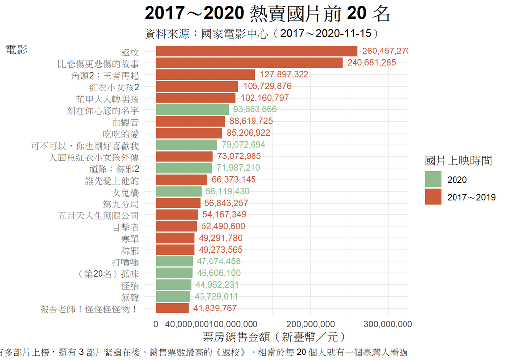

[figure not shown]

```r
### your code
library(scales)

# 清理資料
df_top_local <- df_movie_raw %>%
    rename(movie = 中文片名,
           released_date = 上映日期,
           country = 國別地區,
           grand_total = 累計銷售金額) %>%
    mutate(type = if_else(str_detect(country, "中華民國"), "國片", "國外電影")) %>%
    filter(type == "國片") %>%
    select(year, movie, released_date, grand_total) %>%
    mutate(movie = str_replace_all(movie, "五月天 人生無限公司", "五月天人生無限公司"),
           movie = str_replace_all(movie, "!", "！"),
           movie = str_replace_all(movie, "－", "-"),
           movie = str_replace_all(movie, "THUNDERBOLT FANTASY  生死一劍", "THUNDERBOLT FANTASY 生死一劍"),
           movie = str_replace_all(movie, "THUNDERBOLTFANTASY生死一劍", "THUNDERBOLT FANTASY 生死一劍"),
           movie = str_replace_all(movie, "3260 ＋ 流星安魂曲", "3260＋流星安魂曲"),
           movie = str_replace_all(movie, "報告老師！怪怪 怪怪物！", "報告老師！怪怪怪怪物！")) %>%
    filter(!str_detect(movie, "孤味/繭/擁抱/尋找保羅/Miss World/")) %>%
    mutate(released_date = if_else(is.na(released_date), as.Date(paste(as.character(year), "01-01", sep = "-")), released_date),
           year = as.numeric(year(released_date))) %>%
    arrange(movie, desc(grand_total)) %>%
    distinct(movie, .keep_all = TRUE) %>%
    filter(year %in% c(2017, 2018, 2019, 2020)) %>%
    # 我上網查發現樓下的房客是2016年的電影，因此readr在整理資料時可能有誤，而刪除這筆資料
    arrange(desc(grand_total)) %>%
    slice(1:23) %>%
    mutate(type_by_year = if_else(year != 2020, "2017～2019", "2020"),
           movie = if_else(movie == "孤味", "（第20名）孤味", movie)) %>%
    select(type_by_year, movie, grand_total)

# 繪製橫向長條圖
df_top_local %>%
    mutate(colors = if_else(type_by_year == "2020", "#8FBC8F", "#CD5C3B")) %>%
    ggplot(aes(x = reorder(movie, grand_total), y = grand_total, fill = fct_relevel(type_by_year, "2020", "2017～2019"), label = grand_total)) +
    geom_bar(stat = "identity") +
    geom_text(aes(color = colors, label = comma(grand_total)),
              position = position_dodge(width = 0.5), vjust = 0.35, hjust = -0.1, size = 3) +
    scale_fill_manual(values = c("#8FBC8F", "#CD5C3B")) +
    scale_color_manual(values = c("#8FBC8F", "#CD5C3B"), guide = FALSE) +
    labs(title = "2017～2020 熱賣國片前 20 名",
         subtitle = "資料來源：國家電影中心（2017～2020-11-15）",
         caption = "2020 年有多部片上榜，還有 3 部片緊追在後。銷售票數最高的《返校》，相當於每 20 個人就有一個臺灣人看過",
         x = "電影",
         y = "票房銷售金額（新臺幣／元）",
         fill = "國片上映時間") +
    scale_y_continuous(labels = scales::comma,
                       breaks = c(0, 40000000, 100000000, 200000000, 300000000),
                       limits = c(0, 310000000)) +
    theme_minimal() +
    theme(axis.title.y = element_text(angle = 0),
          plot.title = element_text(face = "bold", size = 18)) +
    coord_flip()
```

## ChatGPT預學作業

1. ColorBrewer是什麼？如何使用ColorBrewer的既定色系來調整顏色？嘗試用ColorBrewer來調整你作業所繪製的圖。

一、臺灣電影每週放映數量

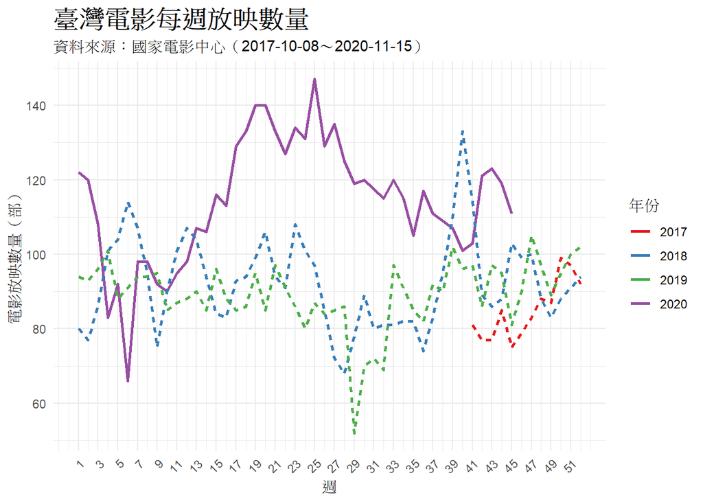

```r
library(RColorBrewer)

# 調整顏色
colors <- brewer.pal(4, "Set1")

picture1 <- df_week_released %>%
    ggplot(aes(x = week, y = number, color = year)) +
    geom_line(size = 0.9, aes(linetype = ifelse(year %in% c("2017", "2018", "2019"), "solid", "dashed"))) +
    scale_color_manual(values = colors) +  # 使用調整後的顏色
    labs(title = "臺灣電影每週放映數量",
         subtitle = "資料來源：國家電影中心（2017-10-08～2020-11-15）",
         x = "週",
         y = "電影放映數量（部）",
         color = "年份") +
    guides(linetype = FALSE) +
    scale_x_continuous(limits = c(1, 52), breaks = seq(1, 52, by = 2)) +
    scale_y_continuous(breaks = seq(0, 150, by = 20)) +
    theme_minimal() +
    theme(axis.text.x = element_text(angle = 45, hjust = 1),
          plot.title = element_text(face = "bold", size = 18))

print(picture1)
```

二、臺灣電影銷售票房變化

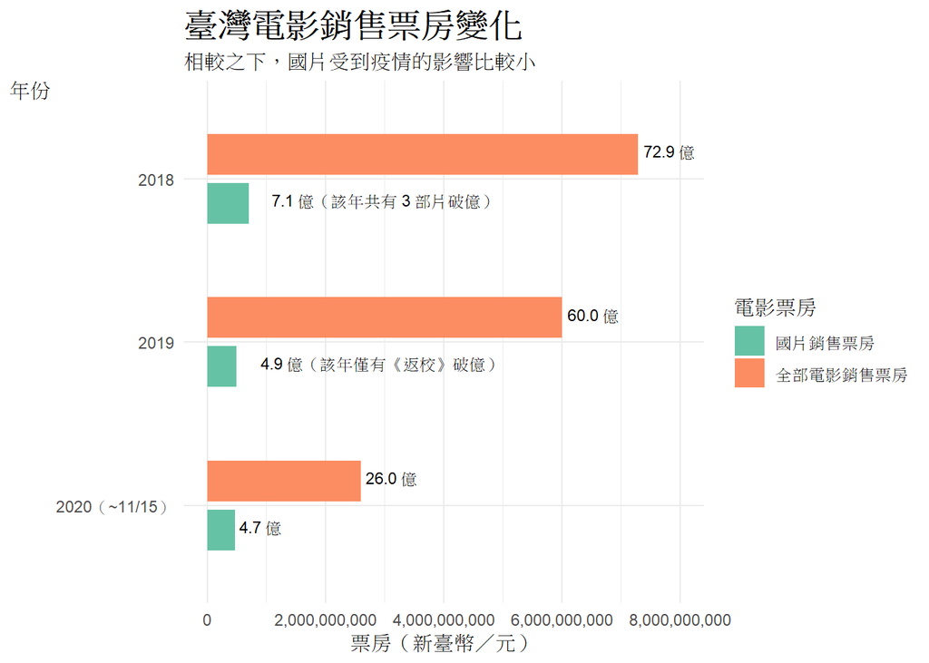

```r
# 調整顏色
colors <- brewer.pal(3, "Set2")

picture2 <- df_box_office %>%
  ggplot(aes(x = fct_relevel(as.factor(year), "2020", "2019", "2018"), y = boxoffice, fill = fct_relevel(電影票房, "國片銷售票房", "全部電影銷售票房"))) +
  geom_bar(stat = "identity", position = position_dodge(width = 0.6), width = 0.5) +
  geom_text(aes(label = case_when(year == "2018" & 電影票房 == "國片銷售票房" ~ paste(round(boxoffice/(10^8), 1), "億（該年共有 3 部片破億）", sep = " "),
                                  year == "2019" & 電影票房 == "國片銷售票房" ~ paste(round(boxoffice / (10^8), 1), "億（該年僅有《返校》破億）", sep = " "),
                                  year == "2019" & 電影票房 == "全部電影銷售票房" ~ paste0(round(boxoffice/(10^8), 1), ".0 億"),
                                  year == "2020" & 電影票房 == "全部電影銷售票房" ~ paste0(round(boxoffice/(10^8), 1), ".0 億"),
                                  TRUE ~ paste(as.character(round(boxoffice / (10^8), 1)), "億", sep = " "))),
            position = position_dodge(width = 0.6), vjust = 0.2, hjust = -0.1, color = "black", size = 3) +
  scale_fill_manual(values = colors) +  # 使用調整後的顏色
  labs(title = "臺灣電影銷售票房變化",
       subtitle = "相較之下，國片受到疫情的影響比較小",
       x = "年份",
       y = "票房（新臺幣／元）",
       fill = "電影票房") +
  scale_y_continuous(labels = scales::comma, breaks = seq(0, 8000000000, by = 2000000000), limits = c(0, 8000000000)) +
  scale_x_discrete(labels = c("2020（~11/15）", "2019", "2018")) +
  theme_minimal() +
  theme(axis.title.y = element_text(angle = 0),
        plot.title = element_text(face = "bold", size = 18)) +
  coord_flip()

print(picture2)
```

三、國片上映院數是否有增加？歷年國片院數上映中位數。

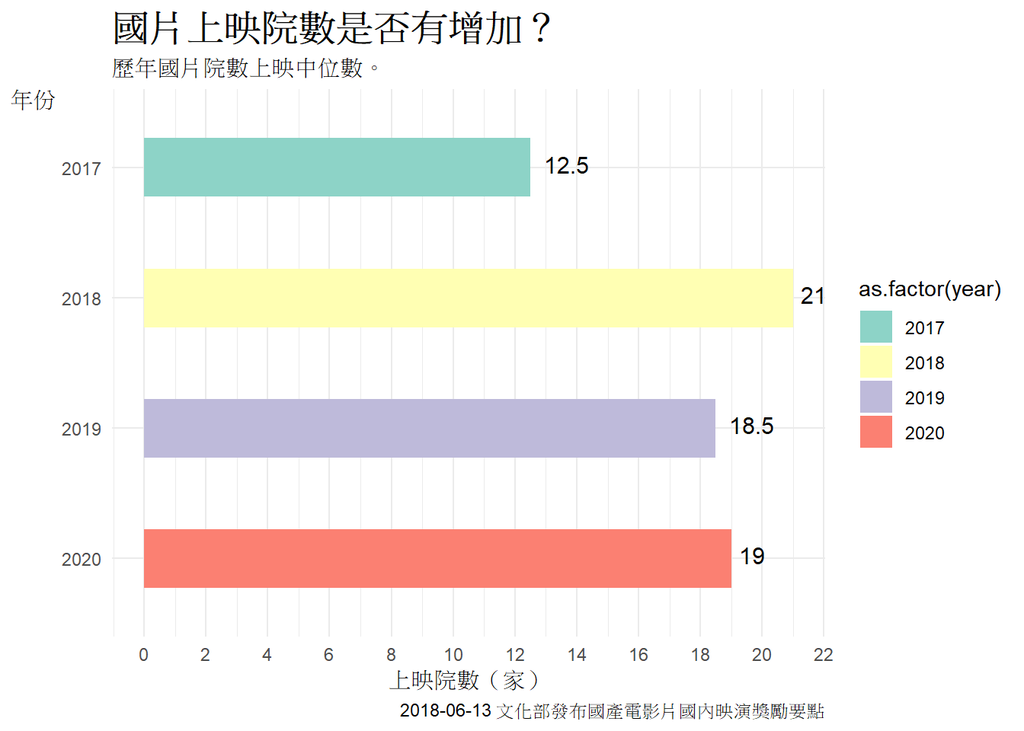

```r
## 調整顏色
colors <- brewer.pal(4, "Set3")  # 設定與資料集中唯一類別數量相符的顏色

picture3 <- df_theaters_median %>%
  ggplot(aes(x = fct_relevel(as.factor(year), "2020", "2019", "2018", "2017"), y = 國片上映院數中位數)) +
  geom_bar(stat = "identity", width = 0.45, aes(fill = as.factor(year))) +
  geom_text(aes(label = 國片上映院數中位數),
            vjust = 0.3, hjust = -0.3, size = 4, color = "black") +  # 修改 color 參數為黑色
  labs(title = "國片上映院數是否有增加？",
       subtitle = "歷年國片院數上映中位數。",
       caption = "2018-06-13 文化部發布國產電影片國內映演獎勵要點",
       x = "年份",
       y = "上映院數（家）") +
  scale_fill_manual(values = colors) +  # 使用調整後的顏色
  scale_y_continuous(breaks = seq(0, 22, by = 2)) +
  theme_minimal() +
  theme(axis.title.y = element_text(angle = 0),
        plot.title = element_text(face = "bold", size = 18)) +
  coord_flip()

print(picture3)
```

四、2017～2020 熱賣國片前 20 名

[figure not shown]

```r
# 調整顏色
colors <- brewer.pal(4, "Paired")  # 生成四種顏色

picture4 <- df_top_local %>%
  ggplot(aes(x = reorder(movie, grand_total), y = grand_total, fill = fct_relevel(type_by_year, "2020", "2017～2019"), label = grand_total)) +
  geom_bar(stat = "identity") +
  geom_text(aes(color = fct_relevel(type_by_year, "2020", "2017～2019")),  # 標籤顏色映射到type_by_year，以保持一致性
            position = position_dodge(width = 0.5), vjust = 0.35, hjust = -0.1, size = 3) +
  scale_fill_manual(values = colors) +
  scale_color_manual(values = c(colors[1], colors[2]), guide = FALSE) +  # 只使用前兩種顏色作為標籤顏色
  labs(title = "2017～2020 熱賣國片前 20 名",
       subtitle = "資料來源：國家電影中心（2017～2020-11-15）",
       caption = "2020 年有多部片上榜，還有 3 部片緊追在後。銷售票數最高的《返校》，相當於每 20 個人就有一個臺灣人看過",
       x = "電影",
       y = "票房銷售金額（新臺幣／元）",
       fill = "國片上映時間") +
  scale_y_continuous(labels = scales::comma,
                     breaks = c(0, 40000000, 100000000, 200000000, 300000000),
                     limits = c(0, 300000000)) +
  theme_minimal() +
  theme(axis.title.y = element_text(angle = 0),
        plot.title = element_text(face = "bold", size = 18)) +
  coord_flip()

print(picture4)
```

2. 有時候我們會需要將繪製的圖片用程式碼儲存成高解析度的圖檔，例如dpi=300的png檔，請問要怎麼做？如果今天我希望存成向量圖，svg或pdf，該怎麼做？請嘗試將你所輸出的圖儲存為png, pdf與svg檔。

```r
# 建立圖片清單
pictures <- list(picture1, picture2, picture3, picture4)

# 儲存圖片
for (i in 1:4) {
  filename <- paste0("picture", i)
  ggsave(paste0(filename, ".png"), plot = pictures[[i]], width = 10, height = 8, units = "in", dpi = 300)
  ggsave(paste0(filename, ".pdf"), plot = pictures[[i]], width = 10, height = 8)
  ggsave(paste0(filename, ".svg"), plot = pictures[[i]], width = 10, height = 8)
}
```